# experiments

Justin Lin

## Min Cost vs. Trosset vs. Bengio

The data is uniform on the cube [-5,5]^3 and the new point is chosen randomly in the cube [-10,10]^3. The data was projected to two dimensions using the Bengio method. This 2D embedding was used to calculate the Min Cost and Trosset points.

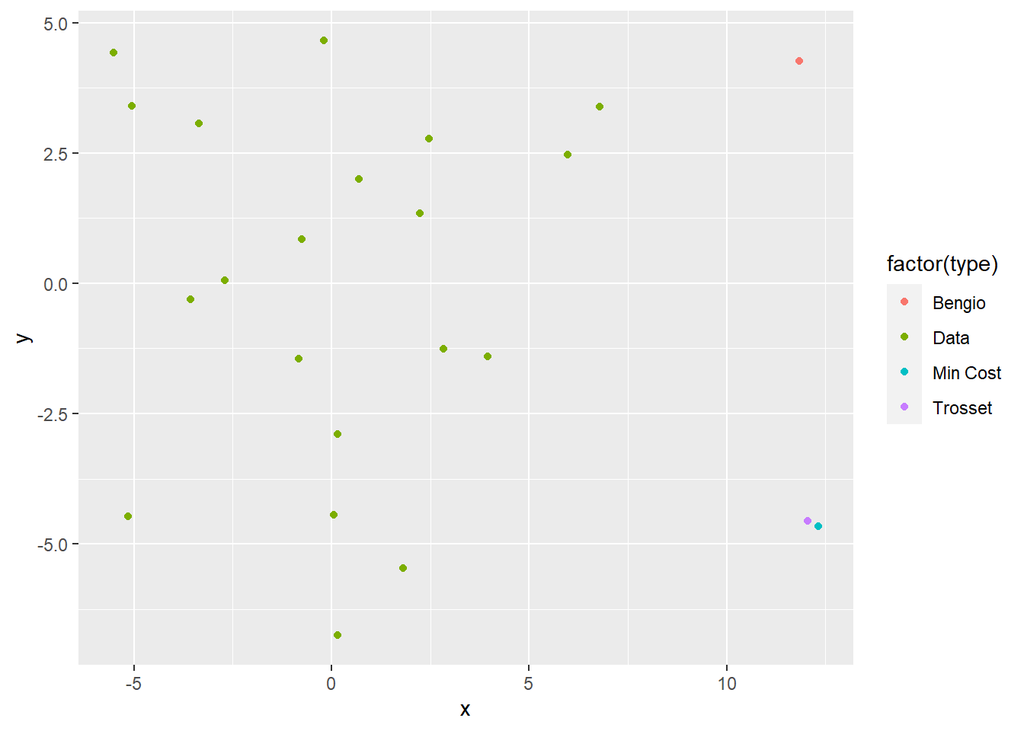

```r
n = 20
data = matrix(runif(3*n, -5, 5), ncol = 3)
proj_data = Bengio_data(data, 2, K_mds)

new_pt = runif(3,-10,10)

a2 = vector(length = n)
for (i in 1:n) {
  a2[i] = dist_sq(new_pt, data[i,])
}

min_cost_pt = min_cost(proj_data, a2, range = 20)$par

Trosset_pt = Trosset(proj_data, compute_dist_sq_mat(proj_data), a2, range = 20)$par

Bengio_pt = Bengio(data, new_pt, 2, K_mds)

plot_data = data.frame(x = c(proj_data[,1], min_cost_pt[1], Trosset_pt[1], Bengio_pt[1]),
                       y = c(proj_data[,2], min_cost_pt[2], Trosset_pt[2], Bengio_pt[2]),
                       type = c(rep("Data", n), "Min Cost", "Trosset", "Bengio"))
ggplot(plot_data, aes(x = x, y = y, color = factor(type))) + geom_point()
```

## Relative Error: Min Cost vs. Trosset

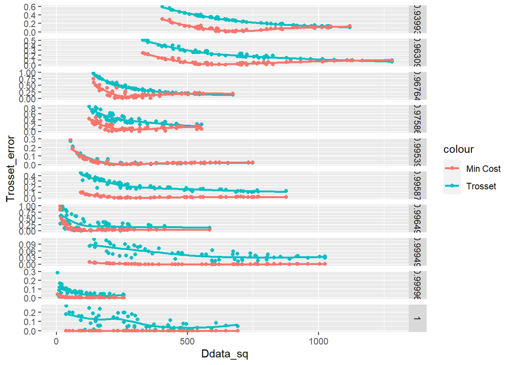

```r
experiment = function(n) {
  proj_data = matrix(runif(2*n, -10, 10), ncol = 2)
  D2 = compute_dist_sq_mat(proj_data)

  rand_point = c(runif(2, -20, 20), runif(1, 0, 20))
  a2 = vector(length = n)
  for (i in 1:n) {
    a2[i] = dist_sq(c(proj_data[i,],0), rand_point)
  }

  new_D2 = rbind(cbind(D2,a2),c(a2,0))
  e = rep(1,n+1)
  P = diag(n+1) - e %*% t(e) / (n+1)
  B = -0.5 * P %*% new_D2 %*% P
  d = svd(B)$d
  emb = round((d[1] + d[2]) / sum(d), digits = 5)

  Trosset_pt = Trosset(proj_data, D2, a2, range = 20)
  Trosset_error = rel_error(Trosset_pt$par, proj_data, a2)

  min_cost_pt = min_cost(proj_data, a2, range = 20)
  min_cost_error = rel_error(min_cost_pt$par, proj_data, a2)

  data.frame(Ddata_sq = a2, Trosset_error, min_cost_error, emb = rep(emb,n))
}

get_data = function(n, runs) {
  data = experiment(n)

  for (i in 2:runs) {
    data = rbind(data, experiment(n))
  }
  data
}

data = get_data(60,10)

p = ggplot(data, aes(x = Ddata_sq, y = Trosset_error, col = "Trosset")) +
  geom_point() +
  geom_smooth(se = FALSE) +
  geom_point(data = data, aes(x = Ddata_sq, y = min_cost_error, col = "Min Cost")) +
  geom_smooth(data = data, aes(x = Ddata_sq, y = min_cost_error, col = "Min Cost"), se = FALSE)
p + facet_grid(rows = vars(emb), scale = "free_y")
```

## Reproducing inter-point distances with error: Min Cost vs. Bengio

The data was uniform in the solid sphere with radius 5. The new points were distances of 2, 5, and 10 away from the origin. The Gaussian error had standard deviation of 1, 2, 5, and 10 in all three coordinates. The Min Cost point was calculated using the 2D Bengio embedding. The mean relative errors in inter- point distances was calculated for both methods in each trial.

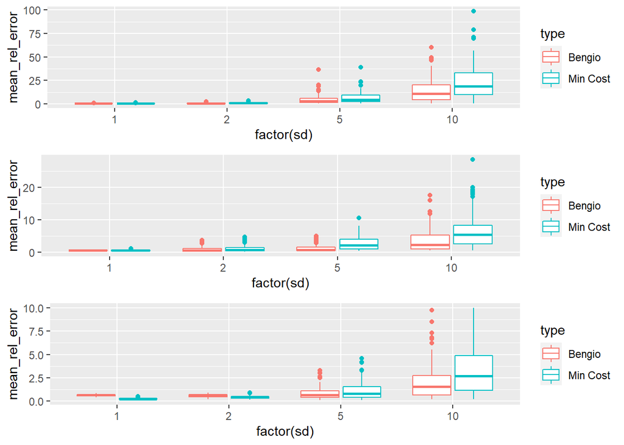

```r
get_rel_errors = function(data, proj_data, base_pt, error_sd) {
  error_pt = base_pt + rnorm(3, 0, error_sd)
  Bengio_pt = Bengio(data, error_pt, 2, K_mds)

  n = length(data[,1])
  a2 = vector(length = n)
  for (i in 1:n) {
    a2[i] = dist_sq(error_pt,data[i,])
  }
  min_cost_pt = min_cost(proj_data, a2, range = 15, iter = +1e06)$par

  base_pt_dists = vector(length = n)
  Bengio_dists = vector(length = n)
  min_cost_dists = vector(length = n)

  for (i in 1:n) {
    base_pt_dists[i] = dist_sq(base_pt, data[i,])
    Bengio_dists[i] = dist_sq(Bengio_pt, proj_data[i,])
    min_cost_dists[i] = dist_sq(min_cost_pt, proj_data[i,])
  }

  cbind(abs(base_pt_dists - min_cost_dists)/base_pt_dists,
        abs(base_pt_dists - Bengio_dists)/base_pt_dists)
}

sim = function(n = 20, b = 100, new_pt, sd) {
  theta = runif(n,0,2*pi)
  phi = runif(n, 0, pi)
  r = 5*(runif(n,0,1))^(1/3)

  x = r*sin(phi)*cos(theta)
  y = r*sin(phi)*sin(theta)
  z = r*cos(phi)

  data = matrix(c(x,y,z), ncol = 3)
  proj_data = Bengio_data(data, 2, K_mds)

  mean_errors = matrix(nrow = b, ncol = 2)
  for (i in 1:b) {
    errors = get_rel_errors(data, proj_data, new_pt, sd)
    mean_errors[i,] = colMeans(errors)
  }

  mean_errors
}

build_box = function(sds, base_pt, data_size = 20) {
  n = length(sds)
  mat = matrix(nrow = n*100, ncol = 3)

  for(i in 1:n) {
    mat[((i-1)*100+1):(i*100),1] = rep(sds[i],100)
    mat[((i-1)*100+1):(i*100),2:3] = sim(n = data_size, new_pt = base_pt, sd = sds[i])
  }
  table = data.frame(sd = c(mat[,1],mat[,1]),
                     mean_rel_error = c(mat[,2],mat[,3]),
                     type = c(rep("Min Cost", n*100), rep("Bengio", n*100)))

  ggplot(table, aes(x = factor(sd), y = mean_rel_error, color = type)) + geom_boxplot()
}

p1 = build_box(c(1,2,5,10), c(2,0,0))
p2 = build_box(c(1,2,5,10), c(5,0,0))
p3 = build_box(c(1,2,5,10), c(10,0,0))
grid.arrange(p1,p2,p3,ncol=1)
```